```python
# Importing Libaries
import sys
!{sys.executable} -m pip install pandas pyarrow numpy scipy seaborn matplotlib scikit-learn six pydotplus
import pandas as pd
import numpy as np
from scipy import stats
import seaborn as sns
import matplotlib.pyplot as plt
from sklearn.cluster import KMeans, DBSCAN
from six import StringIO
```

```
     ━━━━━━━━━━━━━━━━━━━━━━━━━━━━━━━━━━━━━━━ 278.7/278.7 kB 5.7 MB/s eta 0:00:0000:01
  Preparing metadata (setup.py) ... done
```

LE 1.1.1 Calculate the cube root of last 2 digits of your BITSID and paste the details and screenshot of the result.

# BITS ID = 2022AB12524

```python
number = 24
cube_root = round(number ** (1/3),2)
print(f"The cube root is {cube_root}")
```

```
The cube root is 2.88
```

LE 1.1.2 Execute the command help() and explore about list & tuple data type and paste the screen shot.

```python
help(list)
```

```
Help on class list in module builtins:

class list(object)
 |  list(iterable=(), /)
 |  Built-in mutable sequence.
 |  If no argument is given, the constructor creates a new empty list.
 |  The argument must be an iterable if specified.
 |  Methods defined here:
 |  __add__(self, value, /)
 |      Return self+value.
 |  __contains__(self, key, /)
 |      Return bool(key in self).
 |  __delitem__(self, key, /)
 |      Delete self[key].
 |  __eq__(self, value, /)
 |      Return self==value.
 |  __ge__(self, value, /)
 |      Return self>=value.
 |  __getattribute__(self, name, /)
 |      Return getattr(self, name).
 |  __getitem__(self, index, /)
 |      Return self[index].
 |  __gt__(self, value, /)
 |      Return self>value.
 |  __iadd__(self, value, /)
 |      Implement self+=value.
 |  __imul__(self, value, /)
 |      Implement self*=value.
 |  __init__(self, /, *args, **kwargs)
 |      Initialize self.  See help(type(self)) for accurate signature.
 |  __iter__(self, /)
 |      Implement iter(self).
 |  __le__(self, value, /)
 |      Return self<=value.
 |  __len__(self, /)
 |      Return len(self).
 |  __lt__(self, value, /)
 |      Return self<value.
 |  __mul__(self, value, /)
 |      Return self*value.
```

[output cut: 38 more lines]

```
 |      order of two equal elements is maintained).
 |      If a key function is given, apply it once to each list item and sort them,
 |      ascending or descending, according to their function values.
 |      The reverse flag can be set to sort in descending order.
 |  ----------------------------------------------------------------------
 |  Class methods defined here:
 |  __class_getitem__(...) from builtins.type
 |      See PEP 585
 |  ----------------------------------------------------------------------
 |  Static methods defined here:
 |  __new__(*args, **kwargs) from builtins.type
 |      Create and return a new object.  See help(type) for accurate signature.
 |  ----------------------------------------------------------------------
 |  Data and other attributes defined here:
 |  __hash__ = None
```

```python
help(tuple)
```

```
Help on class tuple in module builtins:

class tuple(object)
 |  tuple(iterable=(), /)
 |  Built-in immutable sequence.
 |  If no argument is given, the constructor returns an empty tuple.
 |  If iterable is specified the tuple is initialized from iterable's items.
 |  If the argument is a tuple, the return value is the same object.
 |  Built-in subclasses:
 |      asyncgen_hooks
 |      MonthDayNano
 |      UnraisableHookArgs
 |  Methods defined here:
 |  __add__(self, value, /)
 |      Return self+value.
 |  __contains__(self, key, /)
 |      Return bool(key in self).
 |  __eq__(self, value, /)
 |      Return self==value.
 |  __ge__(self, value, /)
 |      Return self>=value.
 |  __getattribute__(self, name, /)
 |      Return getattr(self, name).
 |  __getitem__(self, key, /)
 |      Return self[key].
 |  __getnewargs__(self, /)
 |  __gt__(self, value, /)
 |      Return self>value.
 |  __hash__(self, /)
 |      Return hash(self).
 |  __iter__(self, /)
 |      Implement iter(self).
 |  __le__(self, value, /)
 |      Return self<=value.
 |  __len__(self, /)
 |      Return len(self).
 |  __lt__(self, value, /)
 |      Return self<value.
 |  __mul__(self, value, /)
 |      Return self*value.
 |  __ne__(self, value, /)
 |      Return self!=value.
 |  __repr__(self, /)
 |      Return repr(self).
 |  __rmul__(self, value, /)
 |      Return value*self.
 |  count(self, value, /)
 |      Return number of occurrences of value.
 |  index(self, value, start=0, stop=9223372036854775807, /)
 |      Return first index of value.
 |      Raises ValueError if the value is not present.
 |  ----------------------------------------------------------------------
 |  Class methods defined here:
 |  __class_getitem__(...) from builtins.type
 |      See PEP 585
 |  ----------------------------------------------------------------------
 |  Static methods defined here:
 |  __new__(*args, **kwargs) from builtins.type
 |      Create and return a new object.  See help(type) for accurate signature.
```

LE 2.1.1 Explore what all operations you can perform with Strings, Lists, Tuples and Dictionary and paste a screen of the console output?

```python
# List Operations
first_list = [1, 2, 3, "data_mining", "ooad"]
# Indexing & Slicing
print(first_list[0])
print(first_list[2:4])

# Appending & Extending
first_list.append("software_architecture")
first_list.extend(["cloud_computing", "machine_learning"])
print(first_list)

# Removing elements
first_list.remove("cloud_computing")
popped_item = first_list.pop(5)
print(first_list)
print(popped_item)
```

[output not shown]

```python
# Tuple Operations
first_tuple = (1, 2, 3, "data_mining", "ooad")
# Indexing & Slicing
print(first_tuple[0])
print(first_tuple[2:4])
# Immutable
```

[output not shown]

```python
# Dictionary Operations
first_dict = {'name': 'Sidhant', 'bits_id': 24, 'course': 'Software Engineering'}

# Read Values
print(first_dict['name'])

# Adding & Modifying
first_dict['occupation'] = 'Engineer'
first_dict['age'] = 26

print(first_dict)

# Remove items
del first_dict['course']
print(first_dict)
```

[output not shown]

LE 3.1.1 Load the IRIS dataset and prepare vector from “sepal_length” data from the dataset and calculate mean, median, mode, variance, five-point summary. Paste the screen shots of each step?

```python
data_file = 'iris.csv'
df_iris = pd.read_csv(data_file)

# Create a vector for sepal length
sepal_length_vector = df_iris['sepal_length']

# Calculate Mean
sepal_length_mean = np.mean(sepal_length_vector)
# Calculate Median
sepal_length_median= np.median(sepal_length_vector)
# Calculate Mode
sepal_length_mode = stats.mode(sepal_length_vector)
# Calculate Variance
sepal_length_variance = np.var(sepal_length_vector)
# Calculate five-point summary
five_point_summary = {
    'Min': np.min(sepal_length_vector),
    '25th Percentile (Q1)': np.percentile(sepal_length_vector, 25),
    'Median (Q2)': np.percentile(sepal_length_vector, 50),
    '75th Percentile (Q3)': np.percentile(sepal_length_vector, 75),
    'Max': np.max(sepal_length_vector)
}

# Display results
print(f"Mean: {sepal_length_mean}")
print(f"Median: {sepal_length_median}")
print(f"Mode: {sepal_length_mode}")
print(f"Variance: {sepal_length_variance}")
print("Five-Point Summary:")
for key, value in five_point_summary.items():
    print(f"{key}: {value}")
```

```
Mean: 5.843333333333334
Median: 5.8
Mode: ModeResult(mode=5.0, count=10)
Variance: 0.6811222222222223
Five-Point Summary:
Min: 4.3
25th Percentile (Q1): 5.1
Median (Q2): 5.8
75th Percentile (Q3): 6.4
Max: 7.9
```

LE 5.4.1 Load the PIMA Dataset and perform following tasks and paste the screen shot for every task. Download the PIMA dataset from the Dataset Link.

LE 5.4.2 Load the PIMA data and print the same and paste the screen shot for task

```python
pima = 'pima-indians-diabetes.csv'
pima_df = pd.read_csv(pima)
print(pima_df)
```

```
     1. Number of times pregnant  \
0                              6
1                              1
2                              8
3                              1
4                              0
..                           ...
763                           10
764                            2
765                            5
766                            1
767                            1

     2. Plasma glucose concentration a 2 hours in an oral glucose tolerance test  \
0                                                  148
```

[output cut: 64 more lines]

```python
# Headers
headers = pima_df.columns
print(headers)
```

```
Index(['1. Number of times pregnant',
       '2. Plasma glucose concentration a 2 hours in an oral glucose tolerance test',
       '3. Diastolic blood pressure (mm Hg)',
       '4. Triceps skin fold thickness (mm)',
       '5. 2-Hour serum insulin (mu U/ml)',
       '6. Body mass index (weight in kg/(height in m)^2)',
       '7. Diabetes pedigree function', '8. Age (years)',
       '9. Class variable (0 or 1)'],
      dtype='object')
```

```python
# Print dimensions of dataset
num_rows, num_columns = pima_df.shape
print("# Rows", num_rows)
print("# Columns", num_columns)
```

```
# Rows 768
# Columns 9
```

```python
# Variable Structure
variable_structure = pima_df.info()
print(variable_structure)
```

```
<class 'pandas.core.frame.DataFrame'>
RangeIndex: 768 entries, 0 to 767
Data columns (total 9 columns):
 #   Column                                                                       Non-Null Count  Dtype
---  ------                                                                       --------------  -----
 0   1. Number of times pregnant                                                  768 non-null    int64
 1   2. Plasma glucose concentration a 2 hours in an oral glucose tolerance test  768 non-null    int64
 2   3. Diastolic blood pressure (mm Hg)                                          768 non-null    int64
 3   4. Triceps skin fold thickness (mm)                                          768 non-null    int64
 4   5. 2-Hour serum insulin (mu U/ml)                                            768 non-null    int64
 5   6. Body mass index (weight in kg/(height in m)^2)                            768 non-null    float64
 6   7. Diabetes pedigree function                                                768 non-null    float64
 7   8. Age (years)                                                               768 non-null    int64
 8   9. Class variable (0 or 1)                                                   768 non-null    int64
dtypes: float64(2), int64(7)
memory usage: 54.1 KB
None
```

```python
# Statistics Summary of the dataset
summary_statistics = pima_df.describe()
print(summary_statistics)
```

```
       1. Number of times pregnant  \
count                   768.000000
mean                      3.845052
std                       3.369578
min                       0.000000
25%                       1.000000
50%                       3.000000
75%                       6.000000
max                      17.000000

       2. Plasma glucose concentration a 2 hours in an oral glucose tolerance test  \
count                                         768.000000
mean                                          120.894531
std                                            31.972618
min                                             0.000000
25%                                            99.000000
50%                                           117.000000
75%                                           140.250000
max                                           199.000000

       3. Diastolic blood pressure (mm Hg)  \
count                           768.000000
mean                             69.105469
std                              19.355807
min                               0.000000
25%                              62.000000
50%                              72.000000
75%                              80.000000
max                             122.000000

       4. Triceps skin fold thickness (mm)  5. 2-Hour serum insulin (mu U/ml)  \
count                           768.000000                         768.000000
mean                             20.536458                          79.799479
std                              15.952218                         115.244002
min                               0.000000                           0.000000
25%                               0.000000                           0.000000
50%                              23.000000                          30.500000
75%                              32.000000                         127.250000
max                              99.000000                         846.000000

```

[output cut: 14 more lines]

```
min                         0.078000       21.000000
25%                         0.243750       24.000000
50%                         0.372500       29.000000
75%                         0.626250       41.000000
max                         2.420000       81.000000

       9. Class variable (0 or 1)
count                  768.000000
mean                     0.348958
std                      0.476951
min                      0.000000
25%                      0.000000
50%                      0.000000
75%                      1.000000
max                      1.000000
```

LE 5.4.5 Find out the min and max of the each variable. You will find some weird records with Zero (0) blood pressure or glucose or insulin. There is requirement of data cleansing with following steps and paste the screen shot for task

```python
# Cleansing the data

# Finding zero values
zero_count = (pima_df == 0).sum()
print("Number of Rows with Zero Values for Each Variable:")
print(zero_count)

# Replace zero values in specific columns with the median
pima_df['2. Plasma glucose concentration a 2 hours in an oral glucose tolerance test'] = pima_df['2. Plasma glucose concentration a 2 hours in an oral glucose tolerance test'].replace(0,np.nan)
pima_df['3. Diastolic blood pressure (mm Hg)'] = pima_df['3. Diastolic blood pressure (mm Hg)'].replace(0,np.nan)
pima_df['5. 2-Hour serum insulin (mu U/ml)'] = pima_df['5. 2-Hour serum insulin (mu U/ml)'].replace(0,np.nan)
```

[output not shown]

```python
non_zero_pima_df = pima_df.dropna()
# min and max of the each variable
min_max_values = non_zero_pima_df.agg(['min', 'max'])
print(min_max_values)
```

```
     1. Number of times pregnant  \
min                            0
max                           17

     2. Plasma glucose concentration a 2 hours in an oral glucose tolerance test  \
min                                               56.0
max                                              198.0

     3. Diastolic blood pressure (mm Hg)  4. Triceps skin fold thickness (mm)  \
min                                 24.0                                    7
max                                110.0                                   63

     5. 2-Hour serum insulin (mu U/ml)  \
min                               14.0
max                              846.0

     6. Body mass index (weight in kg/(height in m)^2)  \
min                                                0.0
max                                               67.1

     7. Diabetes pedigree function  8. Age (years)  9. Class variable (0 or 1)
min                          0.085              21                           0
max                          2.420              81                           1
```

LE 7.4.1 Implement the K-Means clustering algorithm on the IRIS dataset and paste the screen shots.

Check the data for any null values

```python
df_iris.isnull()
```

|  | sepal_length | sepal_width | petal_length | petal_width | species |
| --- | --- | --- | --- | --- | --- |
| 0 | False | False | False | False | False |
| 1 | False | False | False | False | False |
| 2 | False | False | False | False | False |
| 3 | False | False | False | False | False |
| 4 | False | False | False | False | False |
| ... | ... | ... | ... | ... | ... |
| 145 | False | False | False | False | False |
| 146 | False | False | False | False | False |
| 147 | False | False | False | False | False |
| 148 | False | False | False | False | False |
| 149 | False | False | False | False | False |

150 rows × 5 columns

Checking missing values

```python
df_iris.isnull().sum()
```

```
sepal_length    0
sepal_width     0
petal_length    0
petal_width     0
species         0
dtype: int64
```

Checking the value count of the target column i.e. 'Species'

```python
df_iris['species'].value_counts()
```

```
species
setosa        50
versicolor    50
virginica     50
Name: count, dtype: int64
```

```python
target_data = df_iris.iloc[:,4]
target_data.head()
```

```
0    setosa
1    setosa
2    setosa
3    setosa
4    setosa
Name: species, dtype: object
```

```python
clustering_data = df_iris.iloc[:,[0,1,2,3]]
clustering_data.head()
```

|  | sepal_length | sepal_width | petal_length | petal_width |
| --- | --- | --- | --- | --- |
| 0 | 5.1 | 3.5 | 1.4 | 0.2 |
| 1 | 4.9 | 3.0 | 1.4 | 0.2 |
| 2 | 4.7 | 3.2 | 1.3 | 0.2 |
| 3 | 4.6 | 3.1 | 1.5 | 0.2 |
| 4 | 5.0 | 3.6 | 1.4 | 0.2 |

we need to visualize the data which we are going to use for the clustering.

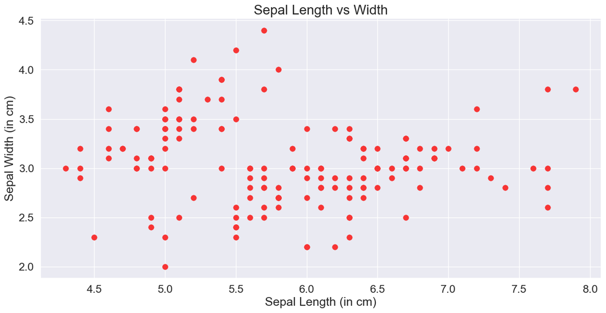

```python
fig, ax = plt.subplots(figsize=(15,7))
sns.set(font_scale=1.5)
ax = sns.scatterplot(x=df_iris['sepal_length'],y=df_iris['sepal_width'], s=70, color='#f73434', edgecolor='#f73434', linewidth=0.3)
ax.set_ylabel('Sepal Width (in cm)')
ax.set_xlabel('Sepal Length (in cm)')
plt.title('Sepal Length vs Width', fontsize = 20)
plt.show()
```

```python
wcss=[]
for i in range(1,11):
    km = KMeans(i)
    km.fit(clustering_data)
    wcss.append(km.inertia_)
np.array(wcss)
```

```
array([680.8244    , 152.36870648,  78.94506583,  71.33622242,
        46.53558205,  38.93096305,  34.56786038,  32.82676162,
        29.54954472,  27.89963352])
```

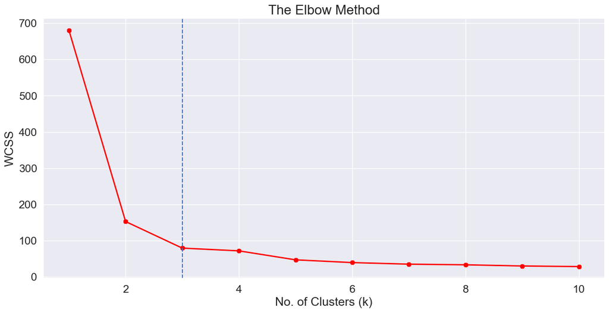

```python
fig, ax = plt.subplots(figsize=(15,7))
ax = plt.plot(range(1,11),wcss, linewidth=2, color="red", marker ="8")
plt.axvline(x=3, ls='--')
plt.ylabel('WCSS')
plt.xlabel('No. of Clusters (k)')
plt.title('The Elbow Method', fontsize = 20)
plt.show()
```

optimal number of clusters for our data are 3, now going for K Means

```python
kms = KMeans(n_clusters=3, init='k-means++')
kms.fit(clustering_data)
```

```
KMeans(n_clusters=3)
```

```python
clusters = clustering_data.copy()
clusters['Cluster_Prediction'] = kms.fit_predict(clustering_data)
clusters.head()
```

|  | sepal_length | sepal_width | petal_length | petal_width | Cluster_Prediction |
| --- | --- | --- | --- | --- | --- |
| 0 | 5.1 | 3.5 | 1.4 | 0.2 | 1 |
| 1 | 4.9 | 3.0 | 1.4 | 0.2 | 1 |
| 2 | 4.7 | 3.2 | 1.3 | 0.2 | 1 |
| 3 | 4.6 | 3.1 | 1.5 | 0.2 | 1 |
| 4 | 5.0 | 3.6 | 1.4 | 0.2 | 1 |

```python
kms.cluster_centers_
```

```
array([[5.9016129 , 2.7483871 , 4.39354839, 1.43387097],
       [5.006     , 3.418     , 1.464     , 0.244     ],
       [6.85      , 3.07368421, 5.74210526, 2.07105263]])
```

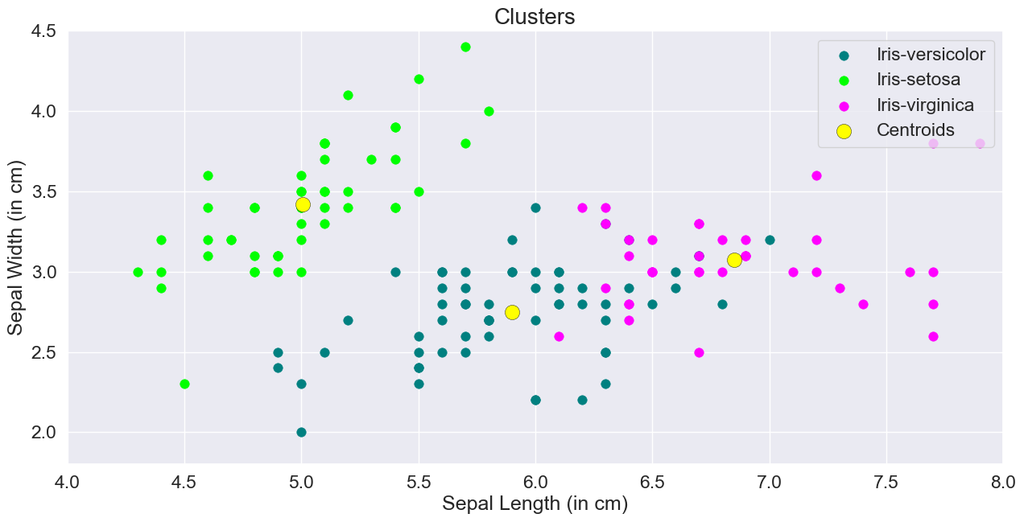

```python
fig, ax = plt.subplots(figsize=(15,7))
plt.scatter(x=clusters[clusters['Cluster_Prediction'] == 0]['sepal_length'],
            y=clusters[clusters['Cluster_Prediction'] == 0]['sepal_width'],
            s=70,edgecolor='teal', linewidth=0.3, c='teal', label='Iris-versicolor')


plt.scatter(x=clusters[clusters['Cluster_Prediction'] == 1]['sepal_length'],
            y=clusters[clusters['Cluster_Prediction'] == 1]['sepal_width'],
            s=70,edgecolor='lime', linewidth=0.3, c='lime', label='Iris-setosa')


plt.scatter(x=clusters[clusters['Cluster_Prediction'] == 2]['sepal_length'],
            y=clusters[clusters['Cluster_Prediction'] == 2]['sepal_width'],
            s=70,edgecolor='magenta', linewidth=0.3, c='magenta', label='Iris-virginica')

plt.scatter(x=kms.cluster_centers_[:, 0], y=kms.cluster_centers_[:, 1], s = 170, c = 'yellow', label = 'Centroids',edgecolor='black', linewidth=0.3)
plt.legend(loc='upper right')
plt.xlim(4,8)
plt.ylim(1.8,4.5)
ax.set_ylabel('Sepal Width (in cm)')
ax.set_xlabel('Sepal Length (in cm)')
plt.title('Clusters', fontsize = 20)
plt.show()
```

Individual Labels clustering for Iris-versicolor

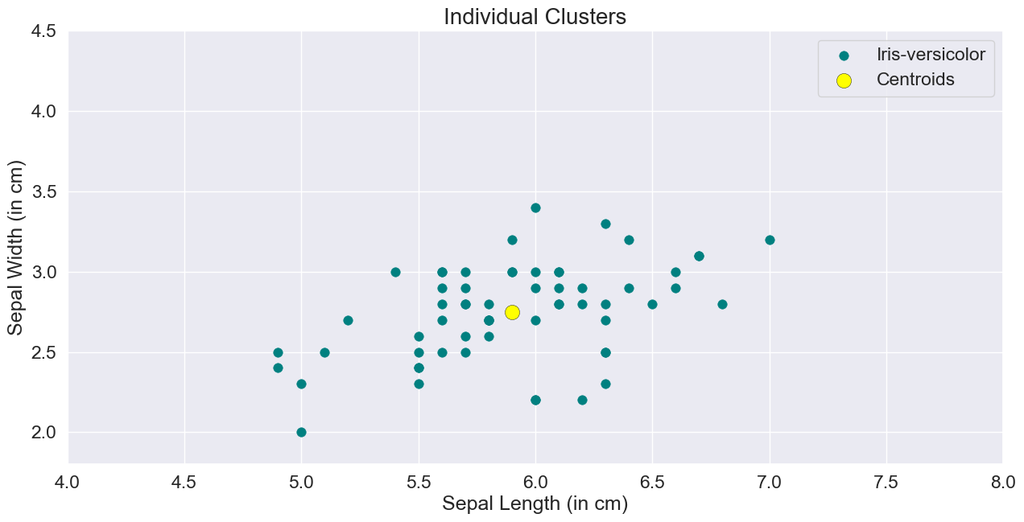

```python
fig, ax = plt.subplots(figsize=(15,7))
plt.scatter(x=clusters[clusters['Cluster_Prediction'] == 0]['sepal_length'],
            y=clusters[clusters['Cluster_Prediction'] == 0]['sepal_width'],
            s=70,edgecolor='teal', linewidth=0.3, c='teal', label='Iris-versicolor')


plt.scatter(x=kms.cluster_centers_[0, 0], y=kms.cluster_centers_[0, 1], s = 170, c = 'yellow', label = 'Centroids',edgecolor='black', linewidth=0.3)
plt.legend(loc='upper right')
plt.xlim(4,8)
plt.ylim(1.8,4.5)
ax.set_ylabel('Sepal Width (in cm)')
ax.set_xlabel('Sepal Length (in cm)')
plt.title('Individual Clusters', fontsize = 20)
plt.show()
```

[figure not shown]

```python
fig, ax = plt.subplots(figsize=(15,7))
plt.scatter(x=clusters[clusters['Cluster_Prediction'] == 1]['sepal_length'],
            y=clusters[clusters['Cluster_Prediction'] == 1]['sepal_width'],
            s=70,edgecolor='lime', linewidth=0.3, c='lime', label='Iris-versicolor')


plt.scatter(x=kms.cluster_centers_[1, 0], y=kms.cluster_centers_[1, 1], s = 170, c = 'yellow', label = 'Centroids',edgecolor='black', linewidth=0.3)
plt.legend(loc='upper right')
plt.xlim(4,8)
plt.ylim(1.8,4.5)
ax.set_ylabel('Sepal Width (in cm)')
ax.set_xlabel('Sepal Length (in cm)')
plt.title('Individual Clusters', fontsize = 20)
plt.show()
```

[figure not shown]

```python
fig, ax = plt.subplots(figsize=(15,7))
plt.scatter(x=clusters[clusters['Cluster_Prediction'] == 2]['sepal_length'],
            y=clusters[clusters['Cluster_Prediction'] == 2]['sepal_width'],
            s=70,edgecolor='magenta', linewidth=0.3, c='magenta', label='Iris-versicolor')


plt.scatter(x=kms.cluster_centers_[2, 0], y=kms.cluster_centers_[2, 1], s = 170, c = 'yellow', label = 'Centroids',edgecolor='black', linewidth=0.3)
plt.legend(loc='upper right')
plt.xlim(4,8)
plt.ylim(1.8,4.5)
ax.set_ylabel('Sepal Width (in cm)')
ax.set_xlabel('Sepal Length (in cm)')
plt.title('Individual Clusters', fontsize = 20)
plt.show()
```

DBSCAN

```python
df_worms = pd.read_csv('worms.csv')
df_worms = df_worms.drop(columns=['Unnamed: 0'])
print(df_worms)
```

```
             X       Y
0       4260.1  3476.0
1       4276.3  3475.6
2       4260.2  3475.3
3       4244.4  3494.8
4       4270.0  3467.1
...        ...     ...
105595  3567.9  3583.4
105596  3383.9  3897.8
105597  3259.6  2970.7
105598  2688.7  2958.6
105599  4095.2  2344.0

[105600 rows x 2 columns]
```

```python
#setting the algorithm prameters
epsilon = 35
min_samples = 145

db = DBSCAN(eps=epsilon, min_samples=min_samples).fit(df_worms)

labels = db.labels_

# Number of clusters in labels, ignoring noise if present.
n_clusters_ = len(set(labels)) - (1 if -1 in labels else 0)
n_noise_ = list(labels).count(-1)

print('Estimated number of clusters: %d' % n_clusters_)
print('Estimated number of noise points: %d' % n_noise_)
```

```
Estimated number of clusters: 28
Estimated number of noise points: 49754
```

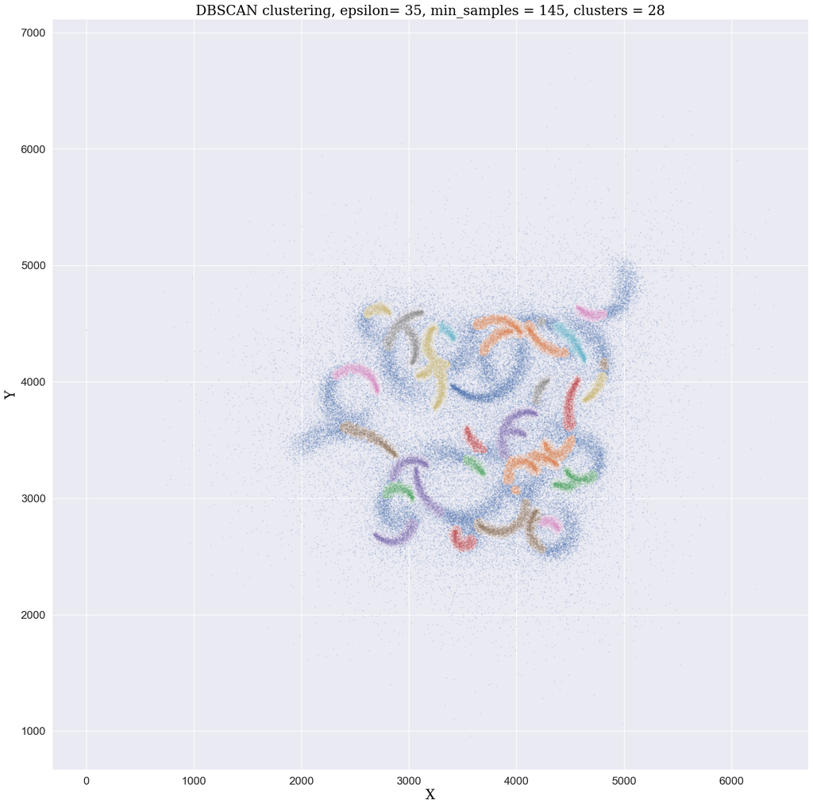

```python
df_worms_clustered = df_worms.copy()
df_worms_clustered.loc[:, "Cluster"] = labels

fig, ax = plt.subplots(figsize=(20, 20))
font1 = {'family':'serif','color':'black','size':20}

plt.xlabel("X", fontdict = font1)
plt.ylabel("Y", fontdict = font1)

groups = df_worms_clustered.groupby("Cluster")
for name, group in groups:
    plt.plot(group["X"], group["Y"], marker=".", markersize=0.3, linestyle="", label=name)


plt.title('DBSCAN clustering, ''epsilon= '+str(epsilon)+', min_samples = '+str(min_samples)+', clusters = '+str(n_clusters_), fontdict = font1)


plt.show()
```

Implement a Decision Tree Classification Algorithm in python using PIMA dataset and paste the screen shots.

```python
pima_df.head()
```

|  | 1. Number of times pregnant | 2. Plasma glucose concentration a 2 hours in an oral glucose tolerance test | 3. Diastolic blood pressure (mm Hg) | 4. Triceps skin fold thickness (mm) | 5. 2-Hour serum insulin (mu U/ml) | 6. Body mass index (weight in kg/(height in m)^2) | 7. Diabetes pedigree function | 8. Age (years) | 9. Class variable (0 or 1) |
| --- | --- | --- | --- | --- | --- | --- | --- | --- | --- |
| 0 | 6 | 148.0 | 72.0 | 35 | NaN | 33.6 | 0.627 | 50 | 1 |
| 1 | 1 | 85.0 | 66.0 | 29 | NaN | 26.6 | 0.351 | 31 | 0 |
| 2 | 8 | 183.0 | 64.0 | 0 | NaN | 23.3 | 0.672 | 32 | 1 |
| 3 | 1 | 89.0 | 66.0 | 23 | 94.0 | 28.1 | 0.167 | 21 | 0 |
| 4 | 0 | 137.0 | 40.0 | 35 | 168.0 | 43.1 | 2.288 | 33 | 1 |